# intern

2023-07-03

```
##   MAX_desat MIN_desat MAX_resat DUREE_event DUREE_desat DUREE_resat DELTA_desat
## 1  96.49853  92.49859  95.49854    50.65625    25.65625    25.00000           4
## 2  95.49854  92.49859  95.49854    43.64062    29.32812    14.31250           3
## 3  95.49854  92.49859  95.49854    28.67188    20.67188     8.00000           3
## 4  97.49851  92.49859  96.49853    53.00000    29.65625    23.34375           5
## 5  95.49854  92.49859  95.49854    61.64062    25.64844    35.99219           3
## 6  95.49854  92.49859  95.49854    59.00000    29.03125    29.96875           3
##   DELTA_resat PENTE_desat PENTE_resat  area_down   area_up
## 1    2.999954  -0.1559074  0.11999817 -108.20191 0.4910765
## 2    2.999954  -0.1022909  0.20960379  -95.84380 0.0000000
## 3    2.999954  -0.1451247  0.37499428  -59.45405 0.0000000
## 4    3.999939  -0.1685985  0.17134946  -87.88383 1.1049274
## 5    2.999954  -0.1169662  0.08335015 -131.86941 0.0000000
## 6    2.999954  -0.1033369  0.10010275 -118.20440 0.0000000
```

```
##    MAX_desat       MIN_desat       MAX_resat      DUREE_event
##  Min.   :92.50   Min.   :77.50   Min.   :92.50   Min.   : 10.01
##  1st Qu.:97.50   1st Qu.:90.50   1st Qu.:97.50   1st Qu.: 35.66
##  Median :98.50   Median :92.50   Median :98.50   Median : 47.36
##  Mean   :97.96   Mean   :92.17   Mean   :97.99   Mean   : 49.53
##  3rd Qu.:98.50   3rd Qu.:94.50   3rd Qu.:98.50   3rd Qu.: 59.98
##  Max.   :99.50   Max.   :96.50   Max.   :99.50   Max.   :119.99
##   DUREE_desat         DUREE_resat        DELTA_desat      DELTA_resat
##  Min.   :  0.00781   Min.   :  0.9922   Min.   : 3.000   Min.   : 3.000
##  1st Qu.: 13.35156   1st Qu.: 17.3340   1st Qu.: 4.000   1st Qu.: 4.000
##  Median : 20.00781   Median : 27.0000   Median : 5.000   Median : 5.000
##  Mean   : 19.46835   Mean   : 30.0637   Mean   : 5.789   Mean   : 5.817
##  3rd Qu.: 26.00781   3rd Qu.: 37.6562   3rd Qu.: 7.000   3rd Qu.: 7.000
##  Max.   :115.66406   Max.   :108.3281   Max.   :18.000   Max.   :22.000
##   PENTE_desat         PENTE_resat        area_down             area_up
##  Min.   :-896.0000   Min.   :0.02821   Min.   :-1738.3937   Min.   :  0.000
##  1st Qu.:  -0.4342   1st Qu.:0.11693   1st Qu.: -173.8067   1st Qu.:  0.000
##  Median :  -0.2924   Median :0.20337   Median : -102.0815   Median :  0.000
##  Mean   :  -3.3534   Mean   :0.32320   Mean   : -130.5218   Mean   : 11.451
##  3rd Qu.:  -0.2023   3rd Qu.:0.38699   3rd Qu.:  -53.1883   3rd Qu.:  8.025
##  Max.   :  -0.0519   Max.   :5.03929   Max.   :   -0.4016   Max.   :209.391
```

```r
# Distance entre le min et 100
desaturations$DD100 = 100 - desaturations$MIN_desat
# Distance entre le min et max
desaturations$DDmax = desaturations$MAX_desat - desaturations$MIN_desat
# Distance entre le min et niveau de base
desaturations$DDbase = baselines$baseline - desaturations$MIN_desat
# Rapport  entre le temps de desaturation et saturation
desaturations$TimeRat = desaturations$DUREE_desat/desaturations$DUREE_resat
# Rapport  entre la pente de desaturation et saturation
desaturations$PenteRat = abs(desaturations$PENTE_desat/desaturations$PENTE_resat)
desaturations$patient <- as.numeric(as.factor(data[, 1]))
```

```
##  [1] "MAX_desat"   "MIN_desat"   "MAX_resat"   "DUREE_event" "DUREE_desat"
##  [6] "DUREE_resat" "DELTA_desat" "DELTA_resat" "PENTE_desat" "PENTE_resat"
## [11] "area_down"   "area_up"     "DD100"       "DDmax"       "DDbase"
## [16] "TimeRat"     "PenteRat"    "patient"
```

[figure not shown]

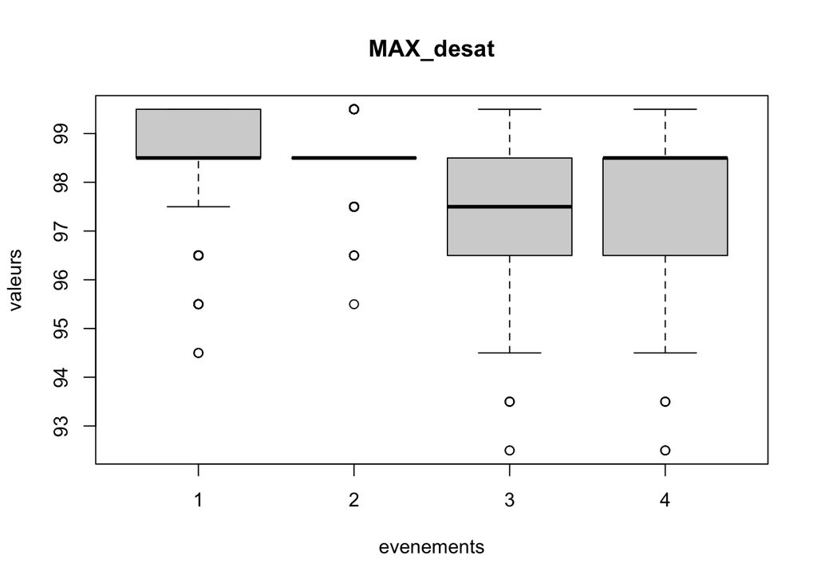

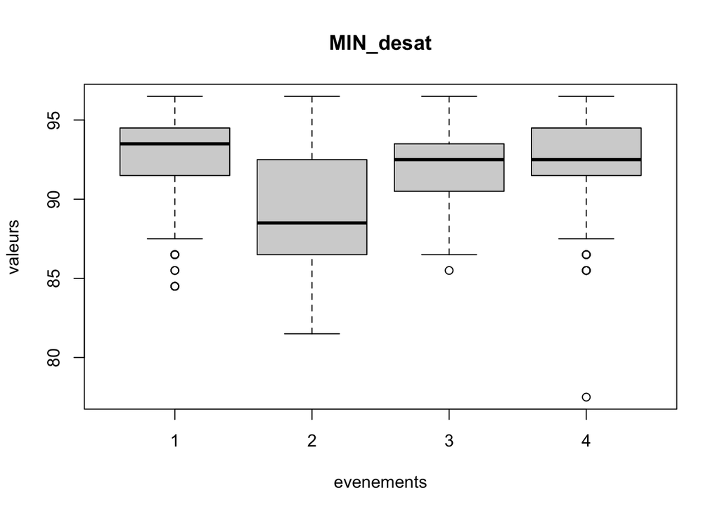

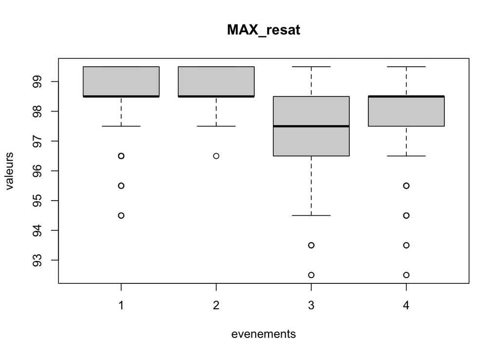

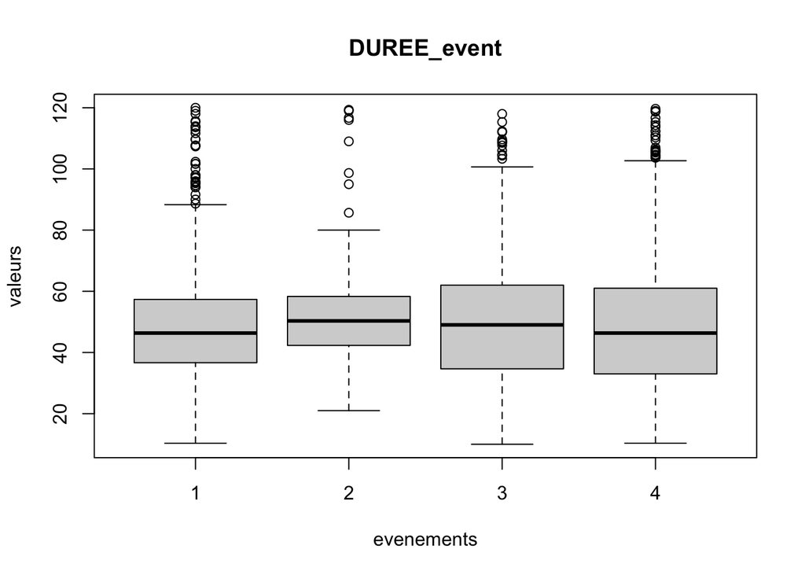

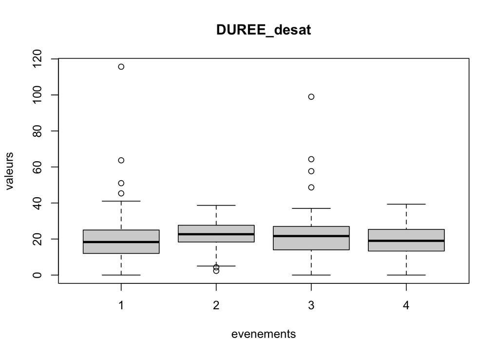

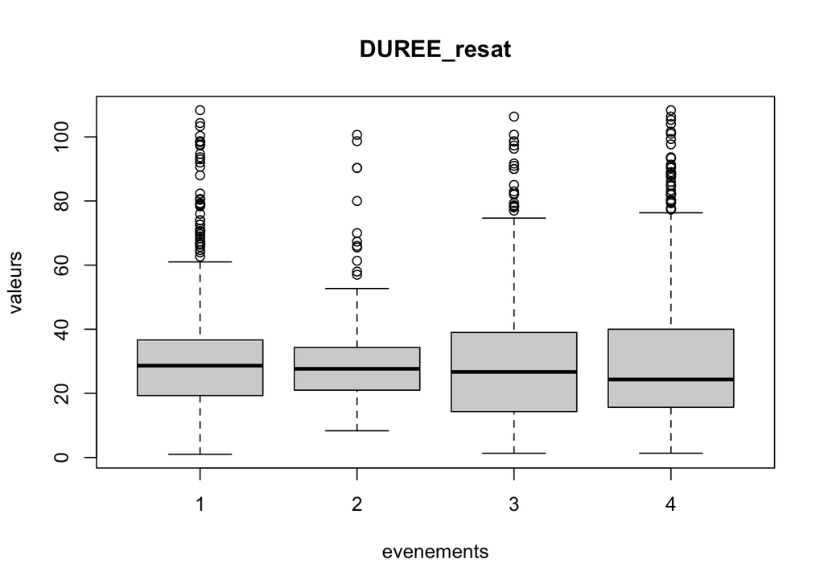

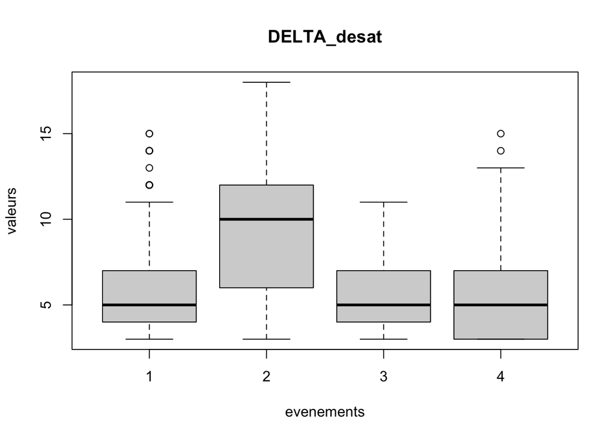

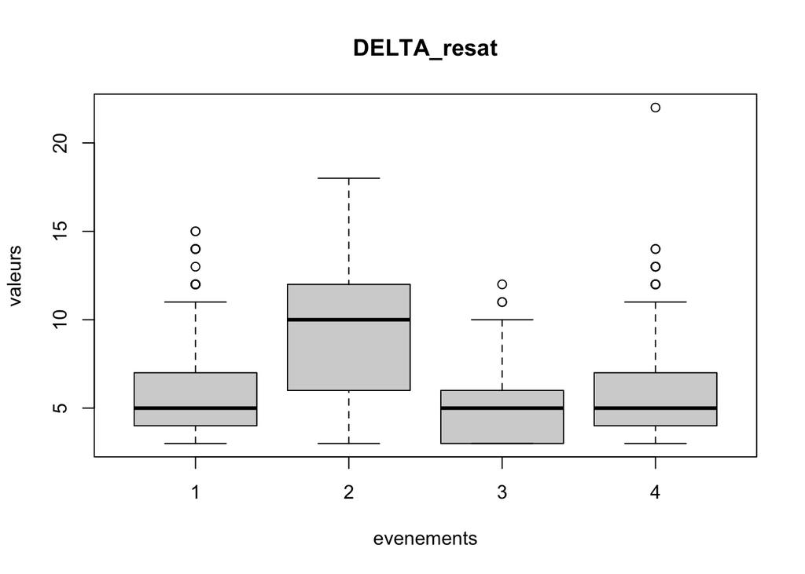

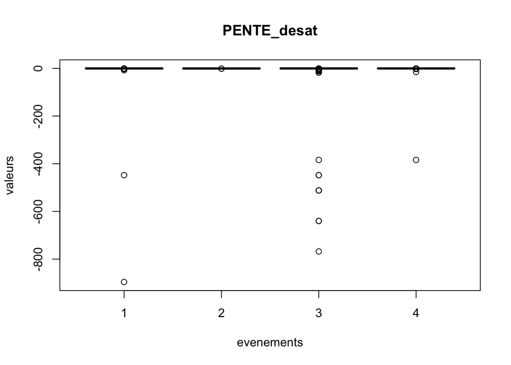

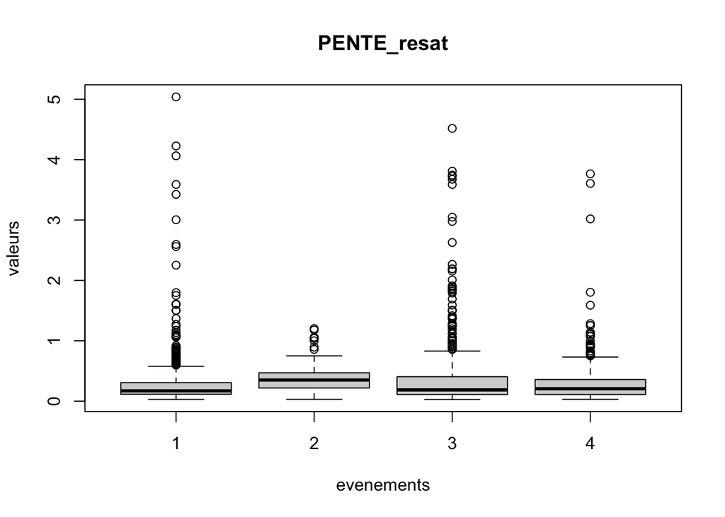

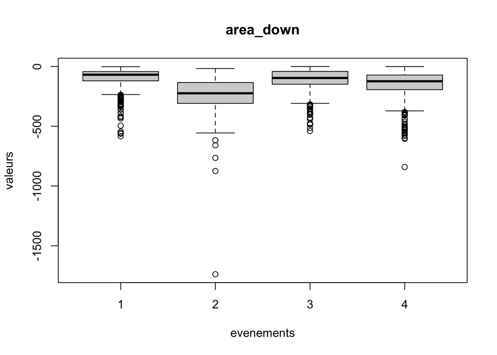

[7 more figures not shown]

```r
pca <- prcomp(desaturations,scale = TRUE)
pc1 <- pca$x[, 1]
pc2 <- pca$x[, 2]
plot(pc1, pc2, pch = 16, col = types, xlab = "PC1", ylab = "PC2",
     main = "2D PCA graph")
legend("topright", legend = c("Apnée centrale","Apnée Obstructive","Hypopnée Centrale","Hypopnée Obstructive"), col = c(1,2,3,4),pch = 16, title = "Evenement")
```

#### Régression logistique multinomiale

[output not shown]

```
## Call:
## multinom(formula = cls ~ MAX_desat + MIN_desat + MAX_resat +
##     DUREE_event + DUREE_desat + DUREE_resat + DELTA_desat + DELTA_resat +
##     PENTE_desat + PENTE_resat + area_down + area_up + DD100 +
##     DDmax + DDbase + TimeRat + patient, data = donnees)
##
## Coefficients:
##    (Intercept)   MAX_desat   MIN_desat   MAX_resat  DUREE_event  DUREE_desat
## 2 -0.009042313 -0.07429226 -0.22205965  0.28554633 -0.032863682 -0.020883139
## 3  0.013260729 -0.06058939  0.19533059 -0.19045141  0.025894324  0.023000933
## 4  0.001331346 -0.11563300  0.06367679  0.04960539 -0.004195662  0.009528652
##    DUREE_resat DELTA_desat DELTA_resat  PENTE_desat PENTE_resat    area_down
## 2 -0.011980548   0.1477697  0.50760598  1.022831274 -4.24003373 -0.008298967
## 3  0.002893399  -0.2559239 -0.38578202 -0.003399716  0.54336514  0.006647182
## 4 -0.013724311  -0.1793125 -0.01407131  0.001517699 -0.09831681 -0.007951132
##        area_up       DD100      DDmax    DDbase     TimeRat    patient
## 2 -0.035520875 -0.68217164  0.1477674 0.1620045  0.06423652 0.16595976
## 3 -0.001978665  1.13074232 -0.2559200 0.0817426 -0.10868529 0.19635058
## 4 -0.010363638  0.06945786 -0.1793098 0.2504464 -0.01767130 0.07210373
##
## Std. Errors:
##    (Intercept)  MAX_desat  MIN_desat  MAX_resat DUREE_event DUREE_desat
## 2 0.0017890222 0.04113911 0.03051051 0.05726402 0.010426708 0.019991806
## 3 0.0009061714 0.02556089 0.01431485 0.03295010 0.003836531 0.006311740
## 4 0.0008609851 0.02481925 0.01364961 0.03172007 0.003892325 0.006261348
##   DUREE_resat DELTA_desat DELTA_resat PENTE_desat PENTE_resat   area_down
## 2 0.012162074  0.04558569  0.08240370 0.677653336   1.4146198 0.001500082
## 3 0.004344235  0.02586793  0.04386305 0.001371392   0.2449104 0.001367366
## 4 0.004301293  0.02508520  0.04202924 0.002629831   0.2971581 0.001190417
##       area_up      DD100      DDmax     DDbase    TimeRat    patient
## 2 0.007927101 0.15489264 0.04558499 0.05605388 0.46252365 0.04234810
## 3 0.002459221 0.08043215 0.02586753 0.03462856 0.03693298 0.02750786
## 4 0.003239739 0.07649096 0.02508482 0.03302518 0.04453934 0.02639392
##
## Residual Deviance: 4523.391
## AIC: 4601.391
```

```
## Likelihood ratio tests of Multinomial Models
##
## Response: cls
##                                                                                                                                                                                                               Model
## 1                                                                                                                                                                                                                 1
## 2 MAX_desat + MIN_desat + MAX_resat + DUREE_event + DUREE_desat + DUREE_resat + DELTA_desat + DELTA_resat + PENTE_desat + PENTE_resat + area_down + area_up + DD100 + DDmax + DDbase + TimeRat + PenteRat + patient
##   Resid. df Resid. Dev   Test    Df LR stat. Pr(Chi)
## 1      6693   5935.144
## 2      6654   4521.250 1 vs 2    39 1413.894       0
```

```
## Likelihood ratio tests of Multinomial Models
##
## Response: cls
##                                                                                                                                                                                                               Model
## 1            MAX_desat + MIN_desat + MAX_resat + DUREE_event + DUREE_desat + DUREE_resat + DELTA_desat + DELTA_resat + PENTE_desat + PENTE_resat + area_down + area_up + DD100 + DDmax + DDbase + TimeRat + patient
## 2 MAX_desat + MIN_desat + MAX_resat + DUREE_event + DUREE_desat + DUREE_resat + DELTA_desat + DELTA_resat + PENTE_desat + PENTE_resat + area_down + area_up + DD100 + DDmax + DDbase + TimeRat + PenteRat + patient
##   Resid. df Resid. Dev   Test    Df LR stat.   Pr(Chi)
## 1      6657   4523.391
## 2      6654   4521.250 1 vs 2     3 2.141062 0.5436504
```

```
## Training Accuracy: 0.5608195
```

```
## Test Accuracy: 0.5597015
```

```r
train_table
```

```
##
## y_train   1   2   3   4
##       1 350  31 119 139
##       2  19 111   3  26
##       3  64   5 217  73
##       4  97  38  72 198
```

```r
test_table
```

```
##
## y_test   1   2   3   4
##      1 147  18  44  66
##      2   8  51   1  11
##      3  35   1  90  27
##      4  39  18  27  87
```

[output not shown]

```
## Call:
## multinom(formula = cls ~ MAX_desat + MIN_desat + MAX_resat +
##     DUREE_event + DUREE_desat + DUREE_resat + DELTA_desat + DELTA_resat +
##     PENTE_desat + PENTE_resat + area_down + area_up + DD100 +
##     DDmax + DDbase + TimeRat + patient, data = donnees)
##
## Coefficients:
##   (Intercept)   MAX_desat  MIN_desat  MAX_resat DUREE_event DUREE_desat
## 2 -0.01055407 -0.08571666 -0.2471583  0.3233162 -0.03282444 -0.02126148
## 3  0.01394477 -0.06373687  0.1999030 -0.1923712  0.01869398  0.01608594
##    DUREE_resat DELTA_desat DELTA_resat  PENTE_desat PENTE_resat    area_down
## 2 -0.011562965   0.1614441   0.5704745  0.926410485  -4.5885543 -0.009509052
## 3  0.002608022  -0.2636438  -0.3922742 -0.002906329   0.3311689  0.005553345
##         area_up      DD100      DDmax    DDbase     TimeRat   patient
## 2 -0.0263324592 -0.8082489  0.1614416 0.1437250  0.19107782 0.1619803
## 3 -0.0009019241  1.1945738 -0.2636398 0.0496277 -0.08375575 0.2469591
##
## Std. Errors:
##    (Intercept)  MAX_desat  MIN_desat  MAX_resat DUREE_event DUREE_desat
## 2 0.0021342340 0.04513790 0.03488644 0.06310835 0.010918659 0.019718878
## 3 0.0009913503 0.02725586 0.01545331 0.03523687 0.003956314 0.006440291
##   DUREE_resat DELTA_desat DELTA_resat PENTE_desat PENTE_resat   area_down
## 2 0.011894142  0.05206123  0.09174476 0.638811232   1.5094948 0.001979489
## 3 0.004707672  0.02757660  0.04710506 0.001358682   0.2424715 0.001448252
##       area_up      DD100      DDmax     DDbase    TimeRat    patient
## 2 0.007015024 0.18445292 0.05206044 0.05884169 0.44619668 0.05117978
## 3 0.002567446 0.08792294 0.02757618 0.03558701 0.03428626 0.03229438
##
## Residual Deviance: 2172.64
## AIC: 2224.64
```

```
## Likelihood ratio tests of Multinomial Models
##
## Response: cls
##                                                                                                                                                                                                               Model
## 1                                                                                                                                                                                                                 1
## 2 MAX_desat + MIN_desat + MAX_resat + DUREE_event + DUREE_desat + DUREE_resat + DELTA_desat + DELTA_resat + PENTE_desat + PENTE_resat + area_down + area_up + DD100 + DDmax + DDbase + TimeRat + PenteRat + patient
##   Resid. df Resid. Dev   Test    Df LR stat. Pr(Chi)
## 1      3208   3284.356
## 2      3182   2172.324 1 vs 2    26 1112.032       0
```

```
## Likelihood ratio tests of Multinomial Models
##
## Response: cls
##                                                                                                                                                                                                               Model
## 1            MAX_desat + MIN_desat + MAX_resat + DUREE_event + DUREE_desat + DUREE_resat + DELTA_desat + DELTA_resat + PENTE_desat + PENTE_resat + area_down + area_up + DD100 + DDmax + DDbase + TimeRat + patient
## 2 MAX_desat + MIN_desat + MAX_resat + DUREE_event + DUREE_desat + DUREE_resat + DELTA_desat + DELTA_resat + PENTE_desat + PENTE_resat + area_down + area_up + DD100 + DDmax + DDbase + TimeRat + PenteRat + patient
##   Resid. df Resid. Dev   Test    Df  LR stat.   Pr(Chi)
## 1      3184   2172.640
## 2      3182   2172.324 1 vs 2     2 0.3155091 0.8540594
```

```
## Training Accuracy: 0.7186109
```

```
## Test Accuracy: 0.6618257
```

```r
train_table
```

```
##
## y_train   1   2   3
##       1 412  61 136
##       2  23 126   5
##       3  87   4 269
```

```r
test_table
```

```
##
## y_test   1   2   3
##      1 175  37  59
##      2  15  44   4
##      3  47   1 100
```

[output not shown]

[output cut: 11 more lines]

[output not shown]

```
## Call:
## multinom(formula = cls ~ MAX_desat + MIN_desat + MAX_resat +
##     DUREE_event + DUREE_desat + DUREE_resat + DELTA_desat + DELTA_resat +
##     PENTE_resat + area_down + area_up + DD100 + DDmax + DDbase +
##     patient, data = donnees)
##
## Coefficients:
##                   Values   Std. Err.
## (Intercept) -0.011966190 0.002263162
## MAX_desat   -0.100332819 0.045411173
## MIN_desat   -0.250251570 0.034426677
## MAX_resat    0.340557572 0.063360816
## DUREE_event -0.021287643 0.007274611
## DUREE_desat  0.002295033 0.010751286
## DUREE_resat -0.023582677 0.008468868
## DELTA_desat  0.149921039 0.052781975
## DELTA_resat  0.590809143 0.091081268
## PENTE_resat -3.950381124 0.970979391
## area_down   -0.009647989 0.001954232
## area_up     -0.020192878 0.006554637
## DD100       -0.946367475 0.195908122
## DDmax        0.149918751 0.052781169
## DDbase       0.178240576 0.061588026
## patient      0.126851222 0.058209566
##
## Residual Deviance: 707.2268
## AIC: 729.2268
```

```
## Likelihood ratio tests of Multinomial Models
##
## Response: cls
##                                                                                                                                                                                                               Model
## 1                                                                                                                                                                                                                 1
## 2 MAX_desat + MIN_desat + MAX_resat + DUREE_event + DUREE_desat + DUREE_resat + DELTA_desat + DELTA_resat + PENTE_desat + PENTE_resat + area_down + area_up + DD100 + DDmax + DDbase + TimeRat + PenteRat + patient
##   Resid. df Resid. Dev   Test    Df LR stat. Pr(Chi)
## 1        -1   1192.470
## 2       -14    705.732 1 vs 2    13 486.7379       0
```

```
## Likelihood ratio tests of Multinomial Models
##
## Response: cls
##                                                                                                                                                                                                               Model
## 1                                    MAX_desat + MIN_desat + MAX_resat + DUREE_event + DUREE_desat + DUREE_resat + DELTA_desat + DELTA_resat + PENTE_resat + area_down + area_up + DD100 + DDmax + DDbase + patient
## 2 MAX_desat + MIN_desat + MAX_resat + DUREE_event + DUREE_desat + DUREE_resat + DELTA_desat + DELTA_resat + PENTE_desat + PENTE_resat + area_down + area_up + DD100 + DDmax + DDbase + TimeRat + PenteRat + patient
##   Resid. df Resid. Dev   Test    Df LR stat.   Pr(Chi)
## 1       -11   707.2268
## 2       -14   705.7320 1 vs 2     3 1.494779 0.6834759
```

```
## Training Accuracy: 0.8614958
```

```
## Test Accuracy: 0.8645161
```

```r
train_table
```

```
##
## y_train   1   2
##       1 514  74
##       2  26 108
```

```r
test_table
```

```
##
## y_test   1   2
##      1 212  35
##      2   7  56
```

##### HDclassif : HDDA et HDDC

$$f(x, \theta) = \sum_{k=1}^{K} \pi_k
\phi(x; \mu_k, \Sigma_k)$$

où $\pi_k$ est la proportion de mélange de la k-ème composante et $\phi$ est la densité gaussienne paramétrée par la moyenne $\mu_k$ et la matrice de covariance $\Sigma_k$ et $K$ le nombre de classes (clusters).

**Pour chaque classe k :** - Proportion : $\pi_k$, représentant la proportion de la classe k. - Vecteur moyen : $\mu_k$, représentant le vecteur moyen de la classe k. - Nombre de dimensions intrinsèques : $d_k$, représentant le nombre de dimensions intrinsèques de la classe k. (Le nombre de variables qui sont réellement pertinentes pour expliquer cette classe ) - Valeurs propres : $a_{kj}$, avec $j \in \{1, \ldots, d_k\}$, représentant les valeurs propres de $\Sigma_k$. - Bruit de la classe : $b_k$, représentant le bruit de la classe. - $\tilde{Q}_k$ : les $d_k$ premiers vecteurs propres de $\Sigma_k$.

Le modele gaussian [akjbkQkdk]:

Le modèle général peut être régularisé : - Au sein de la classe : - $ak_1 = \ldots = ak_{dk} = ak$  
- Entre les classes :  
- $d_1 = \ldots = d_K = d$  
- $Q_1 = \ldots = Q_K = Q$  
- $b_1 = \ldots = b_K = b$  
- $a_{11} = \ldots = a_{K1} = a_1$

```
## Accuracy of HDDA for all evs: 0.266129
```

```
##    cls
##       1   2   3   4
##   1 258  30 231 149
##   2 446 235 260 400
##   3  10   3  41  18
##   4  45   5  41  60
```

```
## Accuracy of HDDA for centrales and obstructives apneas: 0.3570093
```

```
##    cls
##       1   2   3
##   1 269  31 244
##   2 448 236 261
##   3  42   6  68
```

##### HDDC

[output not shown]

```
##    cls
##       1   2   3   4
##   2 666 168 433 489
##   3   3   0  10   2
##   1  61  86 102  89
##   4  29  19  28  47
```

En gardant seulement les apnées centrales et obstructives

```
## Accuracy of HDDC  for centrales and obstructives apneas : 0.5843023
```

```
##    cls
##       1   2
##   2 579 249
##   1 180  24
```